# ENCODE RNA-seq correlation

Guillaume Devailly

## Function definition

We need a few packages:

```r
library(dplyr)
library(readr)
library(cowplot) # load ggplot2
```

We define a function that take two url of ENCODE .tsv file of gene quantification of RNA-seq data from the same species, and return a scatterplot and a Pearson correaltion value.

```r
plotCorrelationOfEncodeTsvSimple <- function(file1url, file2url, label1, label2) {
    file1 <- read_tsv(file1url,  col_types = "cc?????????????")
    file2 <- read_tsv(file2url,  col_types = "cc?????????????")

    pairTable <- inner_join(
        select(file1, gene_id, FPKM),
        select(file2, gene_id, FPKM),
        by = "gene_id"
    ) %>% filter(grepl("ENS", gene_id, fixed = TRUE)) %>% # we keep only ensembl gene
        filter(FPKM.x > 0 | FPKM.y > 0) # we remove genes undetected in both sample. This step does not seems to make much difference on the PCC.

    pcc_fpkm <- cor(pairTable$FPKM.x, pairTable$FPKM.y)

    plot1 <- ggplot(pairTable, aes(x=log10(FPKM.x+1), y=log10(FPKM.y+1))) + geom_point(size=0.8) +
        geom_smooth(method=lm) +
        ggtitle(paste0("PCC: ", round(pcc_fpkm, digits = 4)))

    ggdraw() + draw_plot(plot1, 0, 0, 1, 0.9) +
        draw_label(
            paste0(label1, " vs ", label2, "\n", nrow(pairTable) ," genes"),
            y = 1, vjust = 1
        )
}
```

## Pearson correlation coeeficicent for mouse RNA-seq

Erythrobalst (ENCFF507VSO) and neural tube (ENCFF507QBN) RNA-seq are poorly correalted with each other:

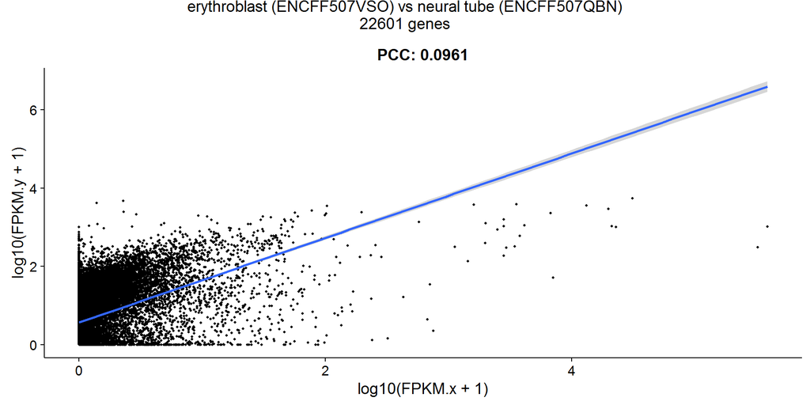

```r
plotCorrelationOfEncodeTsvSimple(
    "https://www.encodeproject.org/files/ENCFF507VSO/@@download/ENCFF507VSO.tsv",
    "https://www.encodeproject.org/files/ENCFF507QBN/@@download/ENCFF507QBN.tsv",
    "erythroblast (ENCFF507VSO)",
    "neural tube (ENCFF507QBN)"
)
```

But neural tube repplicates (ENCSR337FYI) are highly correlated:

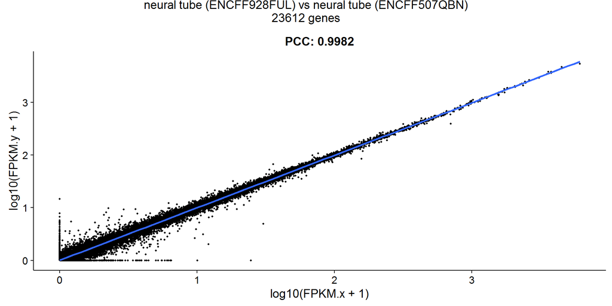

```r
plotCorrelationOfEncodeTsvSimple(
    "https://www.encodeproject.org/files/ENCFF928FUL/@@download/ENCFF928FUL.tsv",
    "https://www.encodeproject.org/files/ENCFF507QBN/@@download/ENCFF507QBN.tsv",
    "neural tube (ENCFF928FUL)",
    "neural tube (ENCFF507QBN)"
)
```

Bladder (ENCFF774MTJ) and adrenal gland (ENCFF584IVW) RNA-seq show intermediate level of correlation:

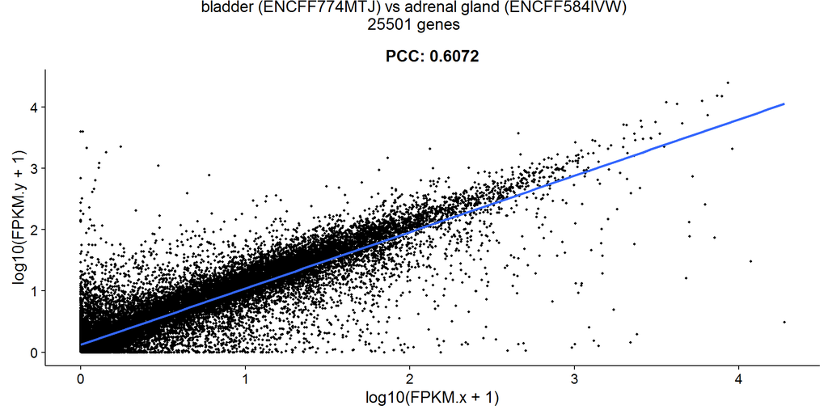

```r
plotCorrelationOfEncodeTsvSimple(
    "https://www.encodeproject.org/files/ENCFF774MTJ/@@download/ENCFF774MTJ.tsv",
    "https://www.encodeproject.org/files/ENCFF584IVW/@@download/ENCFF584IVW.tsv",
    "bladder (ENCFF774MTJ)",
    "adrenal gland (ENCFF584IVW)"
)
```

## Pearson correlation coeeficicent for human RNA-seq

Neural progenitor cell (ENCFF672VVX) and kidney epithelial cell (ENCFF177SUW) have an high PCC despite a resonably disperse scatterplot.

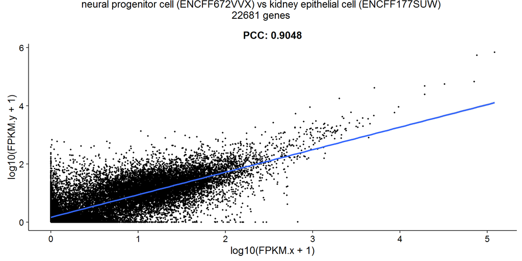

```r
plotCorrelationOfEncodeTsvSimple(
    "https://www.encodeproject.org/files/ENCFF672VVX/@@download/ENCFF672VVX.tsv",
    "https://www.encodeproject.org/files/ENCFF177SUW/@@download/ENCFF177SUW.tsv",
    "neural progenitor cell (ENCFF672VVX)",
    "kidney epithelial cell (ENCFF177SUW)"
)
```

Neural progenitor cell replicates have an high PCC.

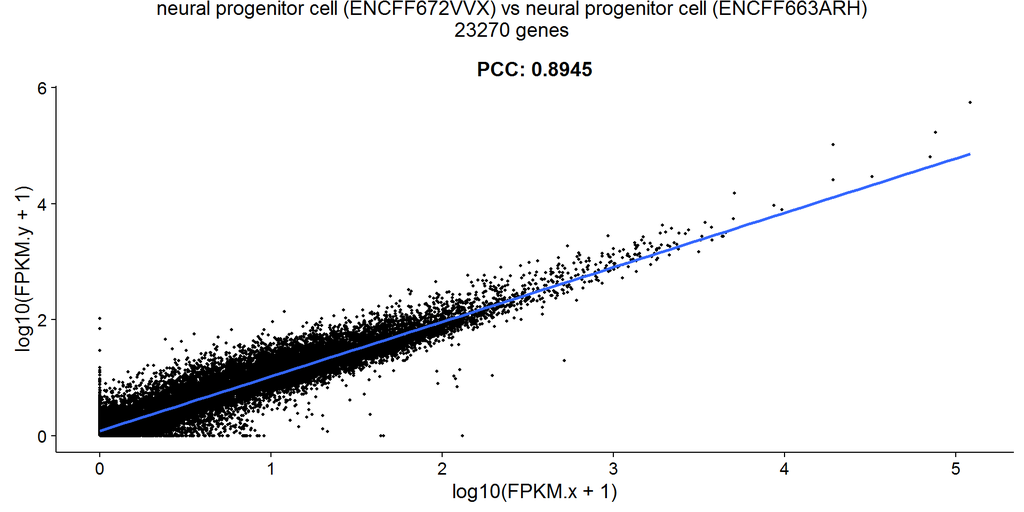

```r
plotCorrelationOfEncodeTsvSimple(
    "https://www.encodeproject.org/files/ENCFF672VVX/@@download/ENCFF672VVX.tsv",
    "https://www.encodeproject.org/files/ENCFF663ARH/@@download/ENCFF663ARH.tsv",
    "neural progenitor cell (ENCFF672VVX)",
    "neural progenitor cell (ENCFF663ARH)"
)
```

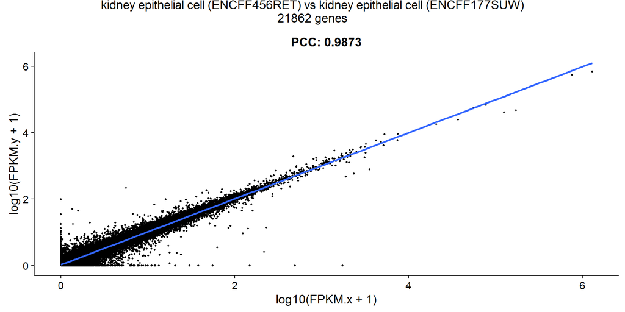

```r
plotCorrelationOfEncodeTsvSimple(
    "https://www.encodeproject.org/files/ENCFF456RET/@@download/ENCFF456RET.tsv",
    "https://www.encodeproject.org/files/ENCFF177SUW/@@download/ENCFF177SUW.tsv",
    "kidney epithelial cell (ENCFF456RET)",
    "kidney epithelial cell (ENCFF177SUW)"
)
```

Lung vs liver:

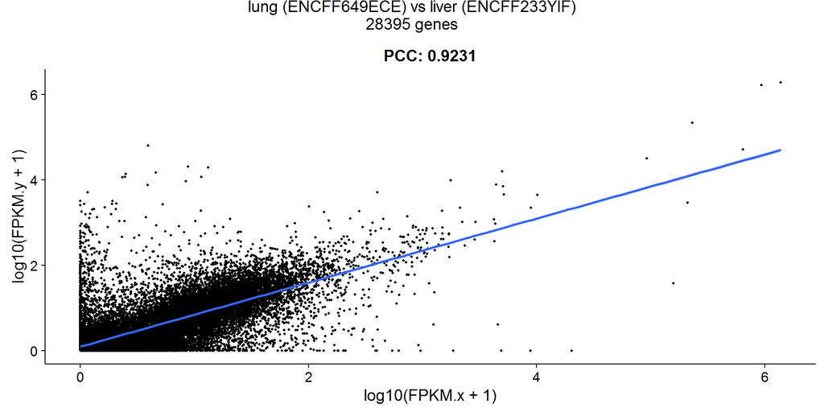

```r
plotCorrelationOfEncodeTsvSimple(
    "https://www.encodeproject.org/files/ENCFF649ECE/@@download/ENCFF649ECE.tsv",
    "https://www.encodeproject.org/files/ENCFF233YIF/@@download/ENCFF233YIF.tsv",
    "lung (ENCFF649ECE)",
    "liver (ENCFF233YIF)"
)
```

Lung vs lung:

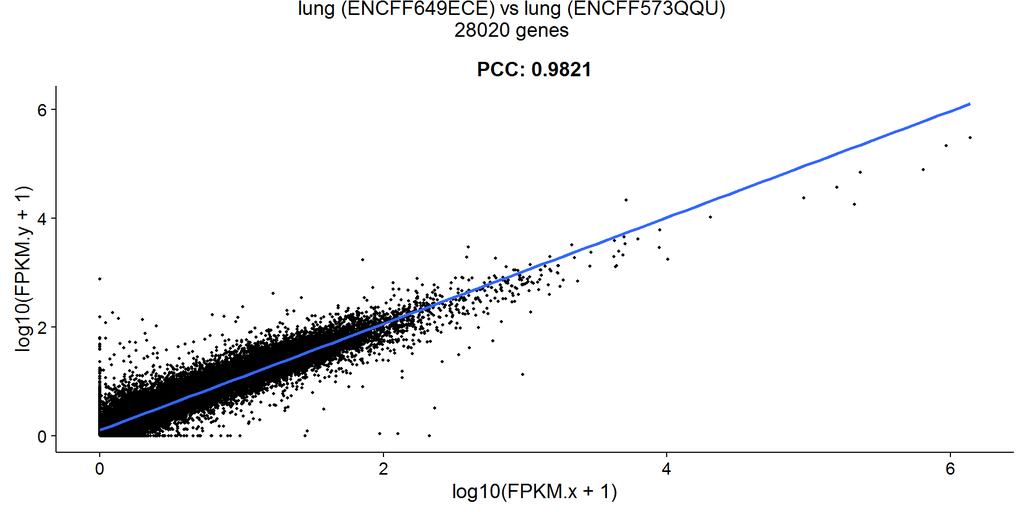

```r
plotCorrelationOfEncodeTsvSimple(
    "https://www.encodeproject.org/files/ENCFF649ECE/@@download/ENCFF649ECE.tsv",
    "https://www.encodeproject.org/files/ENCFF573QQU/@@download/ENCFF573QQU.tsv",
    "lung (ENCFF649ECE)",
    "lung (ENCFF573QQU)"
)
```

## New methods, mouse RNAseq

Let’s see if Spearman correlation, or two normalisation methods of the data, give more meaningfull resuslts:

```r
invnorm = function(x) { #
    res = rank(x)
    res = qnorm(res/(length(res)+0.5))
    return(res)
}

plotCorrelationOfEncodeTsv <- function(file1url, file2url, label1, label2) {
    file1 <- read_tsv(file1url,  col_types = "cc?????????????")
    file2 <- read_tsv(file2url,  col_types = "cc?????????????")

    pairTable <- inner_join(
        select(file1, gene_id, FPKM),
        select(file2, gene_id, FPKM),
        by = "gene_id"
    ) %>% filter(grepl("ENS", gene_id, fixed = TRUE)) %>%
        filter(FPKM.x > 0 | FPKM.y > 0)

    pairTable <- mutate(
        pairTable,
        exp1 = 1/(FPKM.x + 1),
        exp2 = 1/(FPKM.y + 1),
        expb1 = invnorm(FPKM.x),
        expb2 = invnorm(FPKM.y)
    )

    pcc_fpkm <- cor(pairTable$FPKM.x, pairTable$FPKM.y)
    scc_fpkm <- cor(pairTable$FPKM.x, pairTable$FPKM.y, method = "spearman")
    pcc_exp <- cor(pairTable$exp1, pairTable$exp2)
    scc_exp <- cor(pairTable$exp1, pairTable$exp2, method = "spearman")
    pcc_expb <- cor(pairTable$expb1, pairTable$expb2)
    scc_expb <- cor(pairTable$expb1, pairTable$expb2, method = "spearman")

    plot1 <- ggplot(pairTable, aes(x=log10(FPKM.x+1), y=log10(FPKM.y+1))) + geom_point(size=0.8) +
        geom_smooth(method=lm) +
        ggtitle(paste0("PCC: ", round(pcc_fpkm, digits = 4), "\nSCC: ", round(scc_fpkm, digits = 4)))
    plot2 <- ggplot(pairTable, aes(x=exp1, y=exp2)) + geom_point(size=0.8) +
        geom_smooth(method=lm) +
        ggtitle(paste0("PCC: ", round(pcc_exp, digits = 4), "\nSCC: ", round(scc_exp, digits = 4)))
    plot3 <- ggplot(pairTable, aes(x=expb1, y=expb2)) + geom_point(size=0.8) +
        geom_smooth(method=lm) +
        ggtitle(paste0("PCC: ", round(pcc_expb, digits = 4), "\nSCC: ", round(scc_expb, digits = 4)))

    ggdraw() + draw_plot(plot1, 0, 0, 1/3, 0.9) + draw_plot(plot2, 1/3, 0, 1/3, 0.9) + draw_plot(plot3, 2/3, 0, 1/3, 0.9) +
        draw_label(
            paste0(label1, " vs ", label2, "\n", nrow(pairTable) ," genes"),
            y = 1, vjust = 1
        )
}
```

Spearman and normaisation methods raises the correaltion value of unrelated sample.

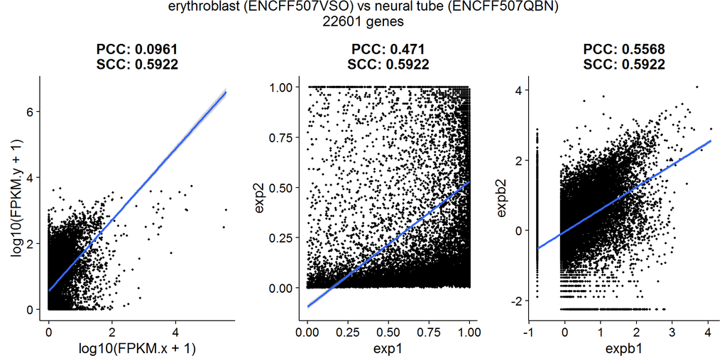

```r
plotCorrelationOfEncodeTsv(
    "https://www.encodeproject.org/files/ENCFF507VSO/@@download/ENCFF507VSO.tsv",
    "https://www.encodeproject.org/files/ENCFF507QBN/@@download/ENCFF507QBN.tsv",
    "erythroblast (ENCFF507VSO)",
    "neural tube (ENCFF507QBN)"
)
```

Neural tube repplicates (ENCSR337FYI) are still highly correlated:

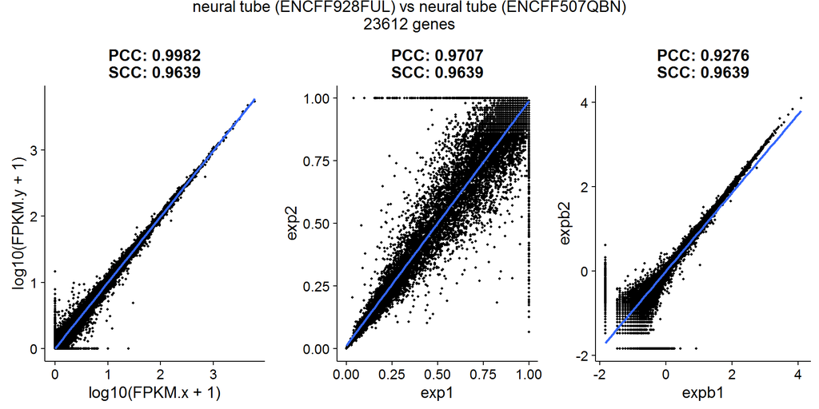

```r
plotCorrelationOfEncodeTsv(
    "https://www.encodeproject.org/files/ENCFF928FUL/@@download/ENCFF928FUL.tsv",
    "https://www.encodeproject.org/files/ENCFF507QBN/@@download/ENCFF507QBN.tsv",
    "neural tube (ENCFF928FUL)",
    "neural tube (ENCFF507QBN)"
)
```

Intermediate level of correlation become a bit high:

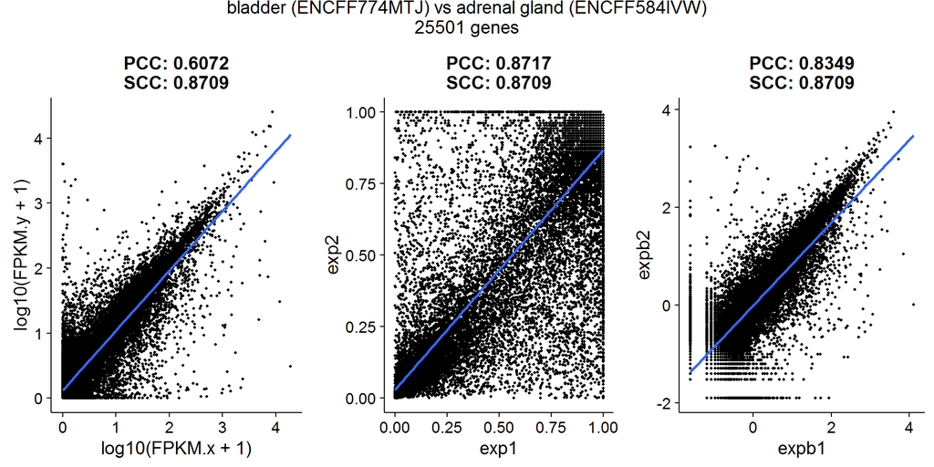

```r
plotCorrelationOfEncodeTsv(
    "https://www.encodeproject.org/files/ENCFF774MTJ/@@download/ENCFF774MTJ.tsv",
    "https://www.encodeproject.org/files/ENCFF584IVW/@@download/ENCFF584IVW.tsv",
    "bladder (ENCFF774MTJ)",
    "adrenal gland (ENCFF584IVW)"
)
```

Spearman and new methods give a more meaningfull value:

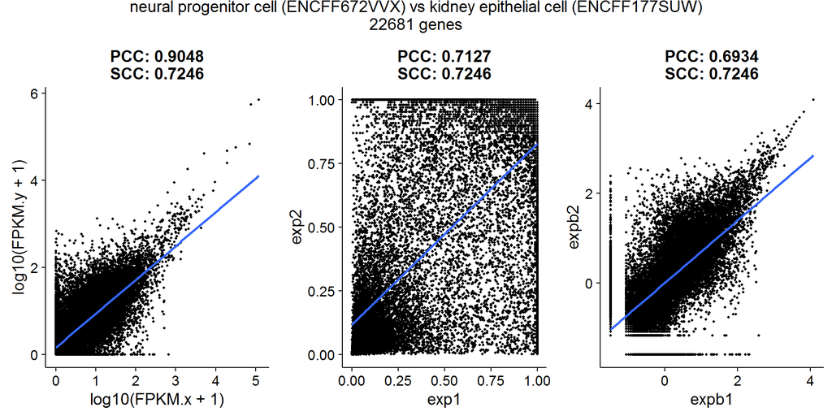

```r
plotCorrelationOfEncodeTsv(
    "https://www.encodeproject.org/files/ENCFF672VVX/@@download/ENCFF672VVX.tsv",
    "https://www.encodeproject.org/files/ENCFF177SUW/@@download/ENCFF177SUW.tsv",
    "neural progenitor cell (ENCFF672VVX)",
    "kidney epithelial cell (ENCFF177SUW)"
)
```

Neural progenitor cell replicates have an high PCC.

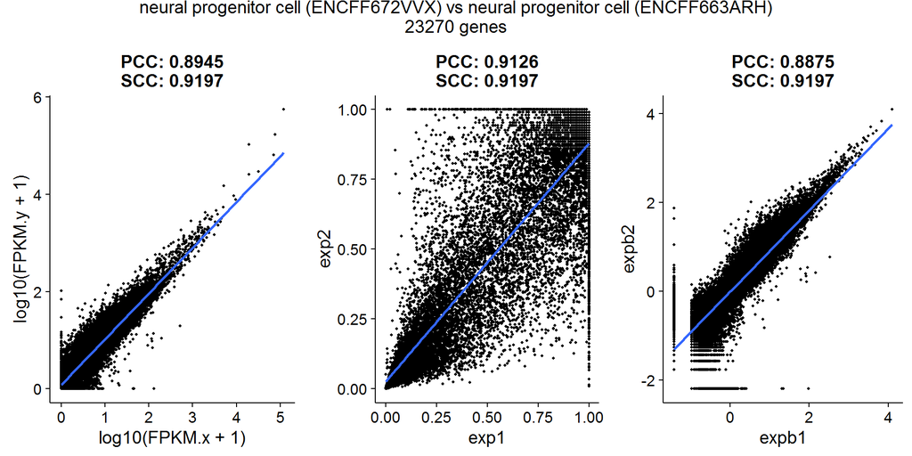

```r
plotCorrelationOfEncodeTsv(
    "https://www.encodeproject.org/files/ENCFF672VVX/@@download/ENCFF672VVX.tsv",
    "https://www.encodeproject.org/files/ENCFF663ARH/@@download/ENCFF663ARH.tsv",
    "neural progenitor cell (ENCFF672VVX)",
    "neural progenitor cell (ENCFF663ARH)"
)
```

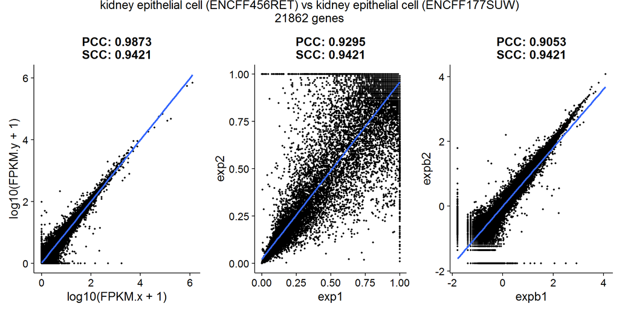

```r
plotCorrelationOfEncodeTsv(
    "https://www.encodeproject.org/files/ENCFF456RET/@@download/ENCFF456RET.tsv",
    "https://www.encodeproject.org/files/ENCFF177SUW/@@download/ENCFF177SUW.tsv",
    "kidney epithelial cell (ENCFF456RET)",
    "kidney epithelial cell (ENCFF177SUW)"
)
```

Spearman and new methods give a more meaningfull value:

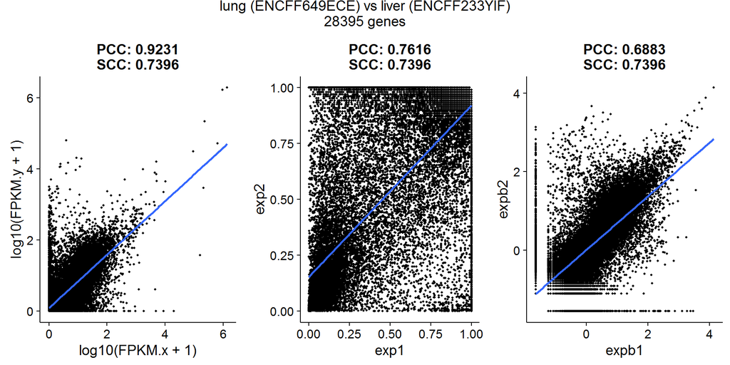

```r
plotCorrelationOfEncodeTsv(
    "https://www.encodeproject.org/files/ENCFF649ECE/@@download/ENCFF649ECE.tsv",
    "https://www.encodeproject.org/files/ENCFF233YIF/@@download/ENCFF233YIF.tsv",
    "lung (ENCFF649ECE)",
    "liver (ENCFF233YIF)"
)
```

Lung vs lung:

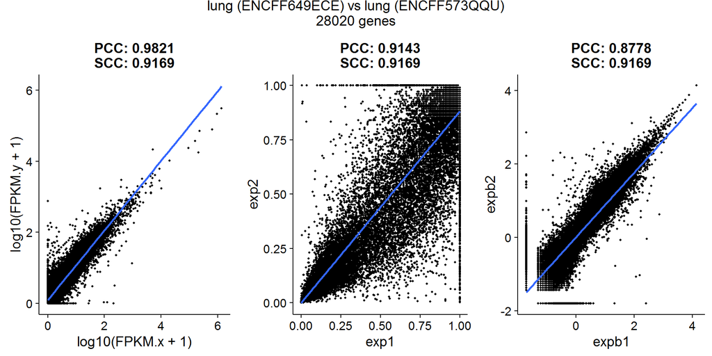

```r
plotCorrelationOfEncodeTsv(
    "https://www.encodeproject.org/files/ENCFF649ECE/@@download/ENCFF649ECE.tsv",
    "https://www.encodeproject.org/files/ENCFF573QQU/@@download/ENCFF573QQU.tsv",
    "lung (ENCFF649ECE)",
    "lung (ENCFF573QQU)"
)
```